# IE48B Homework 1 Rmd- SÜLEYMAN TURANCAN BURUCU

Süleyman Turancan Burucu

11/6/2021

# Gesture Recognition Study

## **1. Reading the Data and Visualization**

> In brief, this homework consists of 3D visualization and representation of the dataset. Given the dataset, it consists of 316 x 896 matrix including 896 movements with class information and 315 acceleration values for each x-axis, y-axis, and z-axis.

First of all, the dataset, consisting of acceleration data for 3-axes, have been read. From the acceleration data, the velocity of the points have been gotten. After getting the velocity, the location information have been gotten from the velocity data.

Calculations of each velocity level was found by cumulative sum of the last two velocity values for each axis:

x_velocity[,3] = x_acceleration[,3] + x_acceleration[,2]

Also, calculations of each location value was found by adding last location value to the half of the sum of last two velocity values for each axis:

x_location[,3] = x_location[,2] + (x_velocity[,3]+x_velocity[,2])/2

Also, the 3D plots were colored in order to see the movement of the points.

After coloring the values, one example from all 8 classes were given and drawn below:

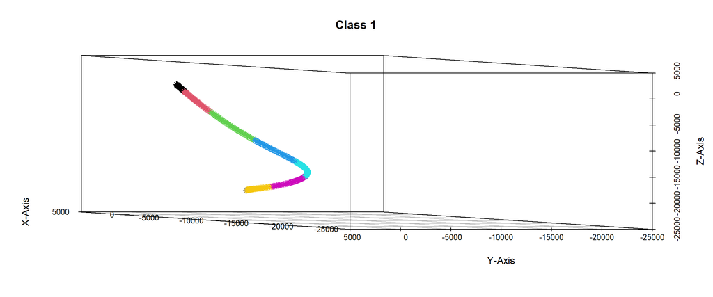

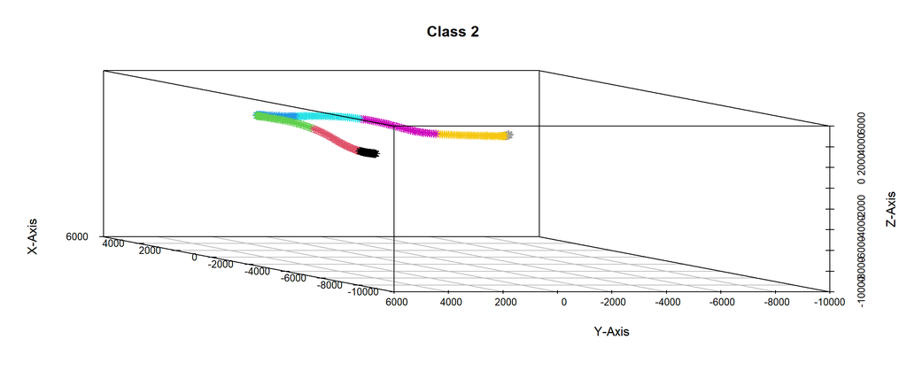

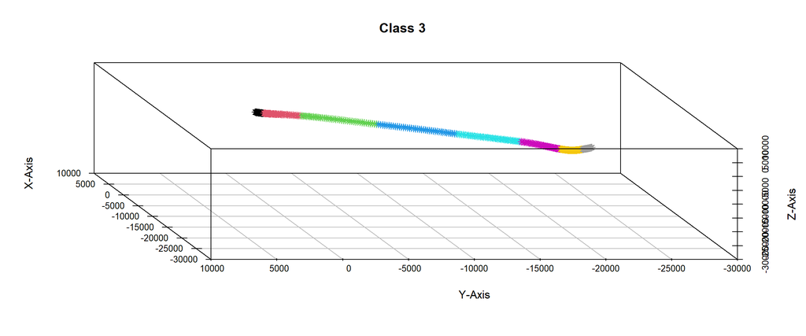

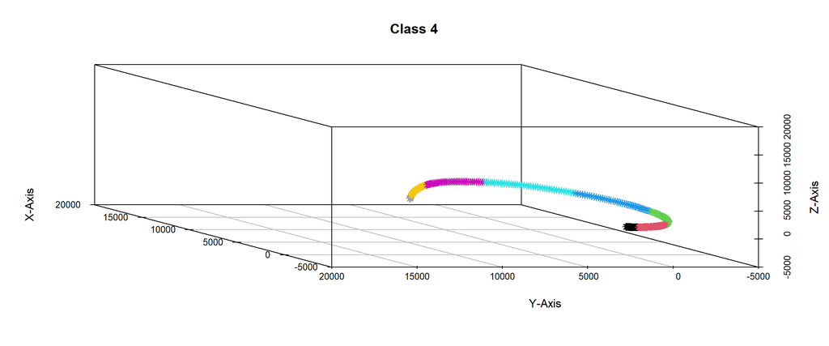

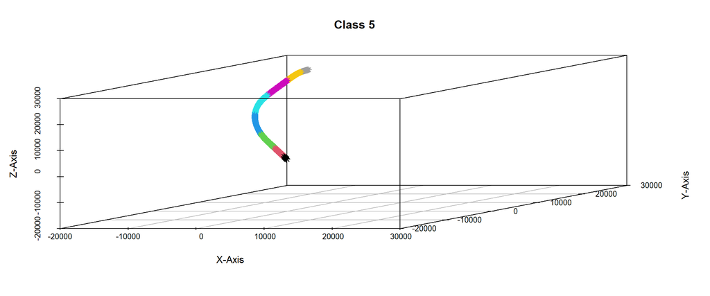

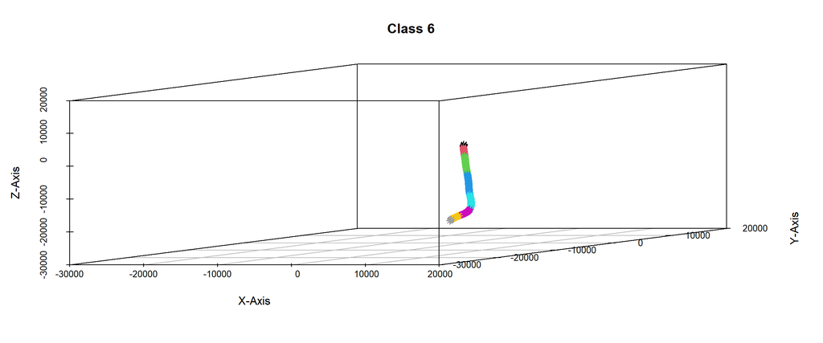

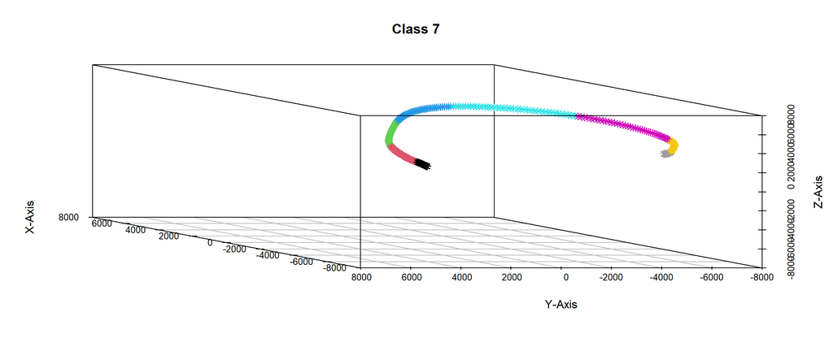

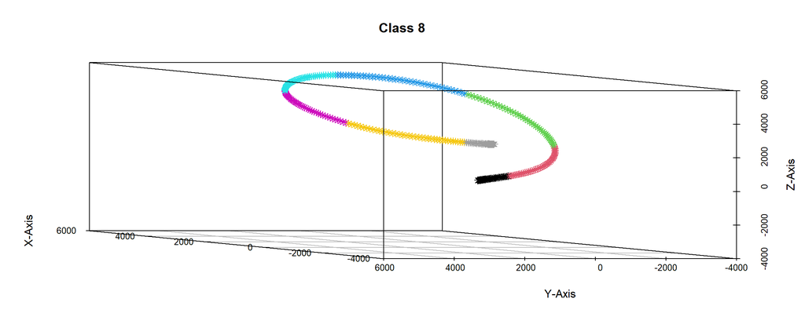

## **2. Time Series Representations**

After providing the graphs from all 8 classes, piecewise aggregate approximation was done for the location values in order to represent the dataset and these representation was drawn. Each point represented the mean of consecutive 35 points. In other words, 316 - 1 = 315 = 9 * 35 points were represented by 9 points. Then, these piecewise aggregate approximation models were drawn, that have nearly perfect similarity with the raw data drawn above.

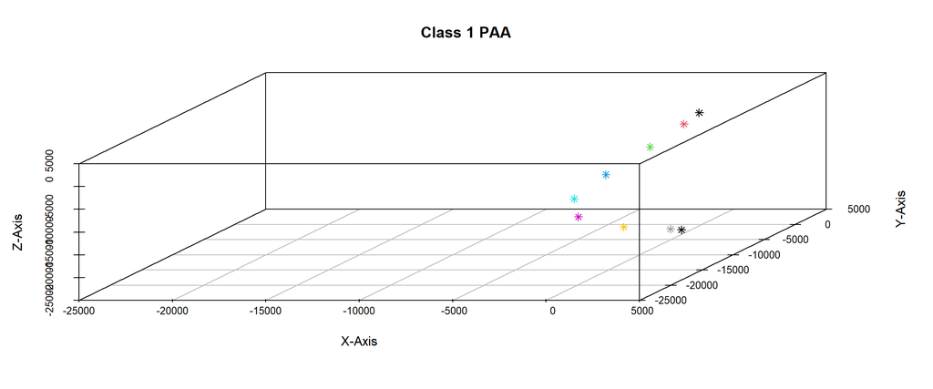

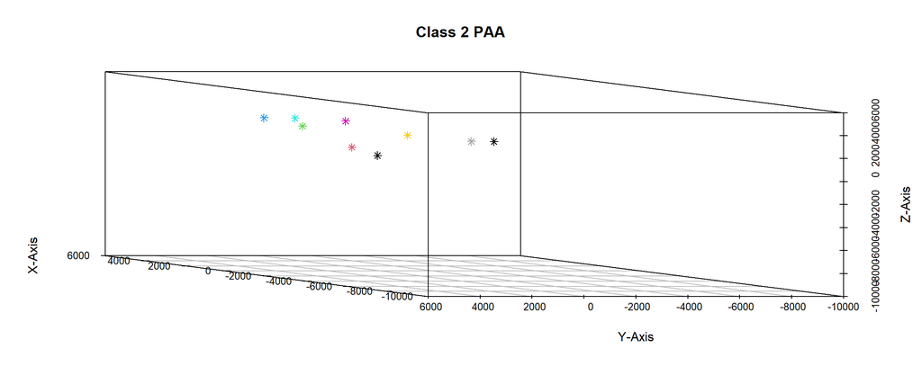

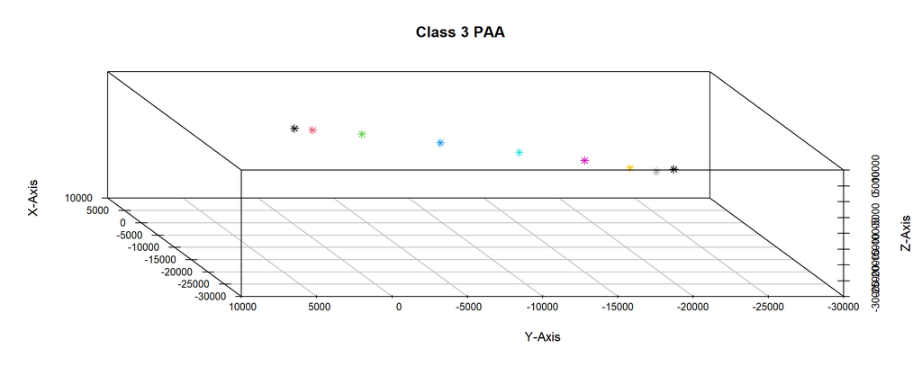

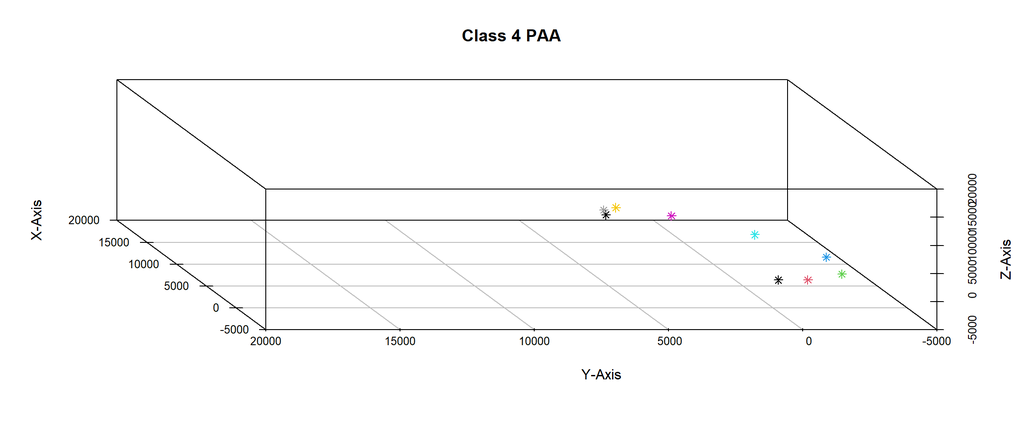

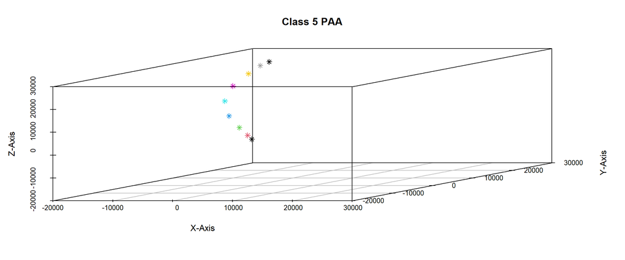

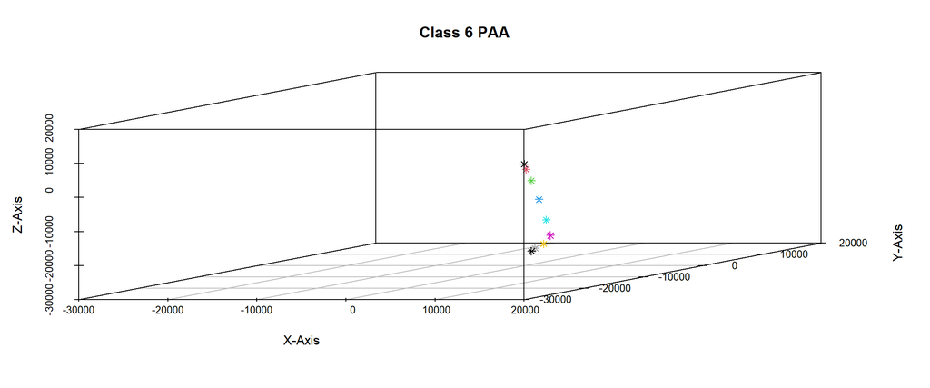

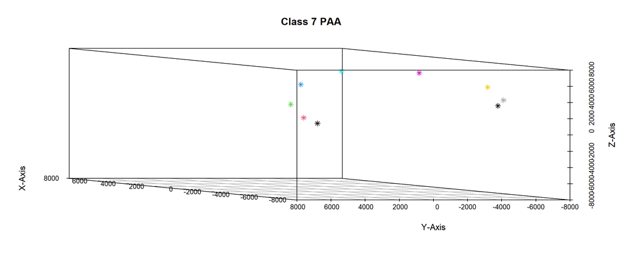

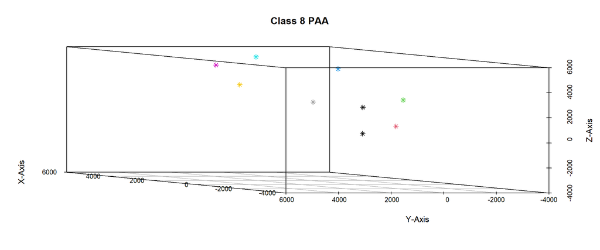

Then, the other representation was symbolic aggregate approximation, which was to assign one letter to each mean values for each axis. For example, if one of the mean value is in between [-30000, -24000], then this interval, consisting of means of consecutive 35 numeric values, was given a letter “a” and so on. We have the first 10 letters of English alphabet which were “a”, “b”, “c”, “d”, “e”, “f”, “g”, “h”, “i”, and “j” used to assign themselves with 9 intervals for each movement. The amount of letters and the intervals were assigned after checking the minimum and the maximum location values of each axis.

```
##   V1 V2 V3 V4 V5 V6 V7 V8 V9 V10
## 1  6  e  e  f  f  f  f  f  f   f
## 2  5  f  f  f  g  h  h  i  i   i
## 3  5  f  f  f  g  g  h  h  h   h
## 4  3  f  e  e  e  e  d  d  c   c
## 5  4  f  f  f  g  h  i  i  j   j
## 6  8  e  e  e  e  e  f  f  f   f
```

```
##   V1 V2 V3 V4 V5 V6 V7 V8 V9 V10
## 1  6  e  e  d  d  c  c  c  c   c
## 2  5  f  f  f  g  g  h  i  i   j
## 3  5  e  e  e  e  f  f  g  g   h
## 4  3  f  f  f  f  f  g  g  f   g
## 5  4  e  e  e  e  f  f  g  g   h
## 6  8  e  e  e  e  e  e  e  e   e
```

```
##   V1 V2 V3 V4 V5 V6 V7 V8 V9 V10
## 1  6  e  e  e  d  c  b  b  b   b
## 2  5  f  f  g  g  h  i  i  i   i
## 3  5  f  f  f  g  g  h  i  i   i
## 4  3  f  f  f  f  g  g  g  f   f
## 5  4  e  e  e  e  e  d  d  c   c
## 6  8  f  f  f  f  g  g  g  g   g
```

As a result, the time series dataset consisting of the locations of 3-axes can be represented by piecewise aggregate approximation and symbolic aggregate approximation. Visually, piecewise aggregate approximation can be felt as more useful since it can be visualized and symbolic aggregate approximation can not due to its structure. Therefore, if I use any representation among these two and need visual results, I will choose piecewise aggregate approximation; otherwise, I will choose symbolic aggregate approximation.